# Global IT Program - Summer 2026 Workshop on Computer Vision

## Prepared by Weijing Ma, Ph.D. P.Eng.

### Activity Overview

This is part of the Global IT series (Humber Polytechnic). This lab is distributed in the format of Jupyter Notebook. You can copy these commands from each cell into other IDEs of your preference (such as PyCharm or Spyder). Please submit the completed .ipynb file to weijing.ma@humber.ca by the end of the day (June 3rd, 2026).  
Please don't distribute this without permission.

### Table of contents

1. Import Needed Packages
2. Basic Image Manipulation
3. Color Detection
4. Pose Detection

### 1. Import Needed packages

### For this lab, the following packages are needed

- **NumPy** (`np`) – provides efficient array operations and numerical computing.
- **OpenCV** (`cv`) – handles image and video processing tasks like reading, transforming, and analyzing visual data.
- **Matplotlib** (`plt`) – used for plotting and visualizing data, such as displaying images or charts.
- **scikit-learn** (`sklearn`) – provides a comprehensive collection of machine learning algorithms.
- **MediaPipe** (`mp`) – a framework for building multimodal applied ML pipelines, including real‑time face detection, hand tracking, and pose estimation.

```python
!pip install opencv-python
```

```python
!pip install opencv-contrib-python
```

```
Downloading opencv_contrib_python-4.13.0.92-cp37-abi3-macosx_13_0_arm64.whl (52.0 MB)
   ━━━━━━━━━━━━━━━━━━━━━━━━━━━━━━━━━━━━━━━━ 52.0/52.0 MB 38.8 MB/s  0:00:01m0:00:0100:01
```

```python
!pip install mediapipe==0.10.35
```

```
Downloading mediapipe-0.10.35-py3-none-macosx_11_0_arm64.whl (17.8 MB)
   ━━━━━━━━━━━━━━━━━━━━━━━━━━━━━━━━━━━━━━━━ 17.8/17.8 MB 42.3 MB/s  0:00:00m0:00:010:01
  Attempting uninstall: mediapipe
    Found existing installation: mediapipe 0.10.30
    Uninstalling mediapipe-0.10.30:
      Successfully uninstalled mediapipe-0.10.30
```

```python
!pip install scikit-image
```

```python
import numpy as np
import cv2 as cv
import matplotlib.pyplot as plt
from sklearn import preprocessing
import mediapipe as mp
```

### 2. Basic Image Manipulation

### In this part, we are going to test some basic image processing techniques

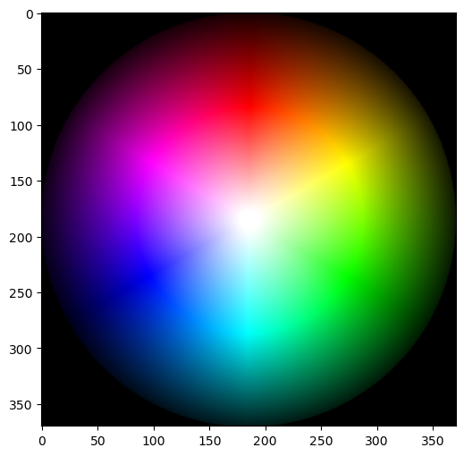

```
Shape: (370, 371, 3)
```

```python
from skimage import data
import matplotlib.pyplot as plt

# import a sample image
original_image = data.colorwheel()   # RGB image

# display it using matplotlib
plt.figure(figsize=(6,6))
plt.imshow(original_image)
plt.axis('on')
plt.show()

# print the size of the image
print("Shape:", original_image.shape)  # (h, w, channels)
```

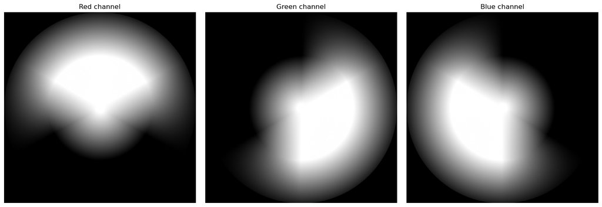

```python
# here we are going to view three channels individually
r, g, b = original_image[:, :, 0], original_image[:, :, 1], original_image[:, :, 2]
titles = ['Red channel', 'Green channel', 'Blue channel']
plt.figure(figsize=(15, 5))
for i, channel in enumerate([r, g, b]):
    plt.subplot(1, 3, i + 1)
    plt.imshow(channel, cmap='grey')
    plt.title(titles[i])
    plt.axis('off')
plt.tight_layout()
plt.show()
```

**Question 1 (10%)**: Why are these images all in grayscale? How to fix this problem and display in corresponding red, green and blue color? Record your code in the cell below.

# Record your solution below

A color image is made of 3 layers stacked together: a Red layer, a Green layer, and a Blue layer. Together, these three layers create a full color picture.

When we use original_image[:, :, 0] to extract just one layer, we get a single 2D array of numbers. The code then uses cmap='gray' inside plt.imshow() which directly tells matplotlib to display it in grayscale, which is why all three channels appear in black and white.

To fix this, we remove cmap='gray' and instead reconstruct a full 3-layer image for each channel, replacing the other two layers with zeros (empty/blank). For example, the red image is built as [R, 0, 0] keeping the red layer and zeroing out green and blue. This way, matplotlib receives a proper RGB image and displays it in the correct color.

### 2.2 Binarization

Now move onto Binarization: it converts numerical valutes into 0's and 1's based on a defined threshold value, anything above it becomes 1 and anything below that becomes 0.

```python
original_data = np.array([[2.1, -0.7, 3.5],[4.4, -7.1, 3.3],[3.7,-4.1,2.5]])
print("\nOriginal data:\n", original_data)
binarized_data = preprocessing.Binarizer(threshold=1.5).transform(original_data)
print("\nBinarized data:\n", binarized_data)
```

```
Original data:
 [[ 2.1 -0.7  3.5]
 [ 4.4 -7.1  3.3]
 [ 3.7 -4.1  2.5]]

Binarized data:
 [[1. 0. 1.]
 [1. 0. 1.]
 [1. 0. 1.]]
```

Similarly, you can use binarization to modify your image.

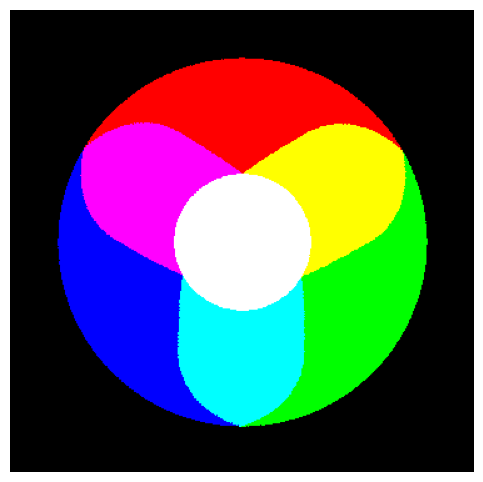

```python
new_image = np.empty(original_image.shape)
for dim in range(original_image.shape[2]):
    new_image[:,:,dim] = preprocessing.Binarizer(threshold=128).transform(original_image[:,:,dim])
# display it using matplotlib
plt.figure(figsize=(6,6))
plt.imshow(new_image)
plt.axis('off')
plt.show()
```

### 2.3 Convolution

As stated in the lecture, convolution is a critical tool for computer vision. Below is an example illustrating the power of image convolution.

```python
from sklearn.datasets import load_sample_image

# Load sample image (RGB)
img = load_sample_image("flower.jpg")

# Define kernels
kernel1 = np.array([
    [0,0,0],
    [0,1,0],
    [0,0,0]
])

kernel2 = np.ones((3,3)) / 9

kernel3 = np.array([
    [0,-1,0],
    [-1,5,-1],
    [0,-1,0]
])

kernel4 = np.array([
    [-1,-1,-1],
    [-1, 8,-1],
    [-1,-1,-1]
])

kernel5 = np.array([
    [-2,-1,0],
    [-1, 1,1],
    [0, 1,2]
])

kernel6 = np.array([
    [0, 1, 0],
    [1,-4, 1],
    [0, 1, 0]
])

kernels = [
    ("Kernel 1", kernel1),
    ("Kernel 2", kernel2),
    ("Kernel 3", kernel3),
    ("Kernel 4", kernel4),
    ("Kernel 5", kernel5),
    ("Kernel 6", kernel6)
]
```

[output not shown]

```python
# Display
plt.figure(figsize=(18,8))

for i, (title, kernel) in enumerate(kernels):

    if kernel is None:
        result = img
    else:
        # apply 2d convolution to input image
        result = cv.filter2D(img, -1, kernel)

    plt.subplot(2,3,i+1)
    plt.imshow(result)
    plt.title(title)
    plt.axis("off")

plt.tight_layout()
plt.show()
```

[output not shown]

[output not shown]

**Question 2 (10%)**: Explain the impact of each convolution kernel to the image.  
Answer:  
**Question 3 (10%)**: If you are planning to apply edge detection algorithm to an image, which kernel (filter) is the most appropriate one? Please provide your rationale.  
Answer:

### 2.4 Camera Control

Your webcam is one of the most accessible imaging sensors. For this lab, we are going to explore its capacity and learn to use OpenCV to manipulate and control it.  
To summarize, you need to:

1. Create a camera object and name it accordingly (in this lab, please name it cap for consistency)
2. Create a capture success flag ret and set its default value to be True
3. Use cap.read() to read in the captured frame and the capture success flag
4. Display the captured frame in a Window
5. Close the display window if any key is pressed

The cell below shows the code sequence to achieve that.

```python
# Open webcam
cap = cv.VideoCapture(0)

if not cap.isOpened():
    print("Cannot open camera")
else:
    cv.namedWindow("test_frame", cv.WINDOW_NORMAL)
    while True:

        # Read a new frame every loop
        ret, frame = cap.read()

        if not ret:
            print("Failed to capture frame")
            break

        # Display updated frame
        cv.imshow("test_frame", frame)

        # Exit when ESC pressed
        key = cv.waitKey(1) & 0xFF
        if key == 27:
            break

# Cleanup
cap.release()
cv.destroyAllWindows()
```

```
Failed to capture frame
```

**Task 4 (20%)**. Now change the code above to implement video streaming in three different windwows, each display a different color channel. When press ESC, all three windows close.  
For individual windows, please apply blurring to the red channel, edge detection to the blue channel, and emboss effect to the green channel. Record your code below.

```python
# write your code here
```

## 3. Color Detection

### Color detection exercise using HSV color space

Sometimes, we need to express color in a different format rather than just RGB. For example, **HSV** is a commonly used way to represent color.

#### HSV Color Model

- **H = Hue** Represents the actual color type (red, orange, yellow, green, blue, etc.). Hue is usually represented as an angle around a color wheel.
- **S = Saturation** Represents the intensity or purity of the color.
  - High saturation → vivid, strong color
  - Low saturation → washed out or closer to gray
- **V = Value** *(also called Brightness)* Represents how bright or dark the color appears.
  - High value → brighter
  - Low value → darker

#### Why is HSV preferred in some computer vision applications?

HSV is often preferred because human visual perception understands **Hue, Saturation, and Value** more naturally than separate Red, Green, and Blue components.

Compared with RGB:

- **Hue** isolates the actual color information.
- **Saturation** controls color intensity independently.
- **Value** controls brightness independently.

This separation makes color-based operations such as **object detection**, **segmentation**, and **tracking** more robust under changing lighting conditions.

Below, we are going to create a **color detection application** that detects specified colors in a video stream.

First, we will start with a **blue color detector**.

To achieve this:

1. Capture video frames from a camera.
2. Convert each captured frame from **RGB/BGR** into **HSV color space**.
3. Define an HSV value range corresponding to the **blue** color.
4. Detect pixels whose HSV values fall within the specified range.
5. Highlight or report the detected blue regions in real time.

```python
import numpy as np
import cv2 as cv

cap = cv.VideoCapture(0)
ret = True
cv.namedWindow('Original',cv.WINDOW_NORMAL)
cv.namedWindow('Mask',cv.WINDOW_NORMAL)
cv.namedWindow('Blue',cv.WINDOW_NORMAL)
while(ret):

    ret, frame = cap.read()

    # Convert BGR to HSV
    hsv = cv.cvtColor(frame, cv.COLOR_BGR2HSV)

    # define range of blue color in HSV
    lower_blue = np.array([100,50,50])
    upper_blue = np.array([140,255,255])

    # create a mask that only pixels within the range of lower_blue and upper_blue
    # will be labeled as 1, other as 0
    mask = cv.inRange(hsv, lower_blue, upper_blue)

    # Bitwise-AND mask and original image
    blue = cv.bitwise_and(frame, frame, mask = mask)

    cv.imshow('Original',frame)
    cv.imshow('Mask',mask)
    cv.imshow('Blue',blue)

    k = cv.waitKey(10) & 0xFF
    if k == 27:
        break
else:
    print('Video capture fault, exit...')

cap.release()
cv.destroyAllWindows()
```

Now change this code to make a tri-color detector. It will analyze the camera stream and to determin if red, yellow or green is detected.  
Hint: please consider the proper choice of the color space and tuning of the color range.  
**Task 5 (20%)** Please record your code in the cell below. Please include the proper comments and annotations to make your code readable. Also, in your code, please comment on why RGB is not a good color space for this application.

```python
# Please record your entire code with proper comments here.
```

### 4. Pose Detection

#### Introduction to Pose Detection Using MediaPipe

MediaPipe Pose extracts a set of predefined **body key points (landmarks)** from each detected person. Each landmark contains:

- **x-coordinate** → horizontal position of the key point
- **y-coordinate** → vertical position of the key point
- **z-coordinate** → estimated depth relative to the camera
- **visibility score** → confidence that the landmark is visible

The pose model detects **33 body landmarks**, covering the face, torso, arms, hands, and legs.

In this exercise, we will use MediaPipe to detect human body landmarks and extract pose key points from a live video stream for further analysis and visualization.

```python
import cv2 as cv
import mediapipe as mp

pose = mp.solutions.pose.Pose()
draw = mp.solutions.drawing_utils
style = mp.solutions.drawing_styles

cap = cv.VideoCapture(0)

while cap.isOpened():

    ret, frame = cap.read()
    if not ret:
        break

    results = pose.process(
        cv.cvtColor(frame, cv.COLOR_BGR2RGB)
    )

    if results.pose_landmarks:
        draw.draw_landmarks(
            frame,
            results.pose_landmarks,
            mp.solutions.pose.POSE_CONNECTIONS,
            landmark_drawing_spec=
                style.get_default_pose_landmarks_style()
        )

    cv.imshow(
        "Pose Detection",
        cv.flip(frame, 1)
    )

    if cv.waitKey(1) & 0xFF == 27:
        break

cap.release()
pose.close()
cv.destroyAllWindows()
```

[output not shown]

**Question 6 (10%)**. Why do we convert the frame from BGR to RGB before calling pose.process()?  
Answer:  
**Question 7 (20%)**. Please name one real-world application of pose detection and explain how it can be implemented based on what we have learned so far. Hint: connect with ML/DL techiques that we have learned in previous sessions.  
Answer:

```python
# Optional: record your implementation in this cell below.
```

## Congratulations, you have completed all hands-on activities on Computer Vision! Please submit this notebook file to weijing.ma@humber.ca with your full name and GlobalIT as the email title.